# Approximation of the distribution function of $N(0, 1)$

Sunrongxue

2020/3/25

## 1 **Abstract**

Monte Carlo method is also known as Random Sampling method or Statistical expertiment method. It is a method based on probailistic statistical thory, the observed values of some experimental results are obtained on the basis of kowned distribution sampling, and the approximate solution of the problem is obtained according to the discribed process.

## 2 **Math Equation**

### 2.1 The standard normal distribution

The equation for the standard normal distribution $N(0, 1)$ is

$$Phi(t) = \int_{- \infty}^t \frac{1}{\sqrt{2\pi}} e^{-y^2 / 2}dy$$
### 2.2 The Monte Carlo method

The equation for the Monte Carlo method is

$$\hat\Phi(t) = \frac{1}{n} \sum_{i=1}^n I(X_i \le t)$$
where $X_i$ is a random sample from $N(0, 1)$, $I(\cdot)$ is the indicator function. Then, experiment with the approximation at $n \in \{10^2, 10^3, 10^4\}$ at $t \in \{0.0, 0.67, 0.84, 1.28, 1.65, 2.32, 2.58, 3.09, 3.72\}$ to form a table.

## 3 **Table**

The approximation results are shown in the table.

```r
t = c(0, 0.67, 0.84, 1.28, 1.65, 2.32, 2.58, 3.09, 3.72)
n = c(100, 1000, 10000)
p = matrix(0, nrow=9, ncol=3)
a = 0
for(i in 1:9)
  for(j in 1:3){
    a = a+1
    num = rnorm(n[j], 0, 1)
    p[i, j] = mean(num<t[i])
    print(a)
  }
```

[output not shown]

```r
rownames(p)<-t
colnames(p)<-n

library(knitr)
library(magrittr)
library(kableExtra)
library(callr)
library(webshot)

kable(p, booktabs=TRUE, caption='(ref:norm)') %>%
  kable_styling(bootstrap_options = "striped",full_width = F) %>%
  column_spec(1,bold=T)
```

|  | 100 | 1000 | 10000 |
| --- | --- | --- | --- |
| 0 | 0.51 | 0.515 | 0.5022 |
| 0.67 | 0.70 | 0.779 | 0.7457 |
| 0.84 | 0.79 | 0.802 | 0.8028 |
| 1.28 | 0.88 | 0.897 | 0.8944 |
| 1.65 | 0.97 | 0.944 | 0.9488 |
| 2.32 | 0.97 | 0.992 | 0.9898 |
| 2.58 | 0.99 | 0.997 | 0.9948 |
| 3.09 | 1.00 | 1.000 | 0.9990 |
| 3.72 | 1.00 | 1.000 | 0.9999 |

## 4 **figure**

After repeat the experiment 100 times, I draw box plots of the 100 approximation errors at each $t$ using **ggplot2** for each $n$.

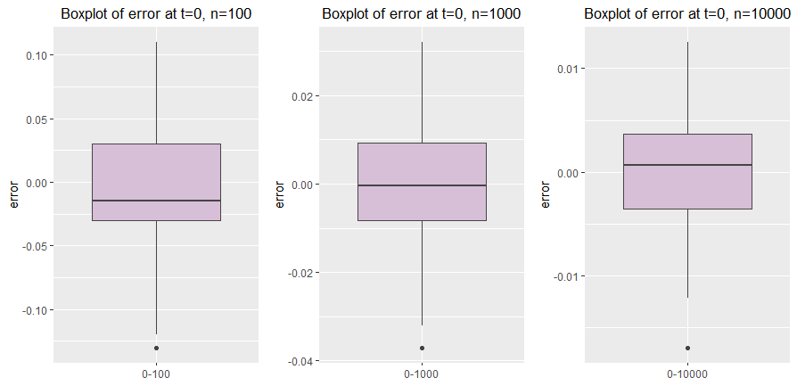

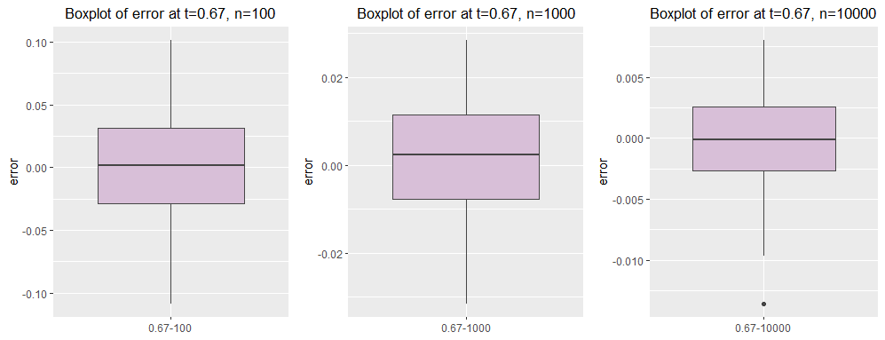

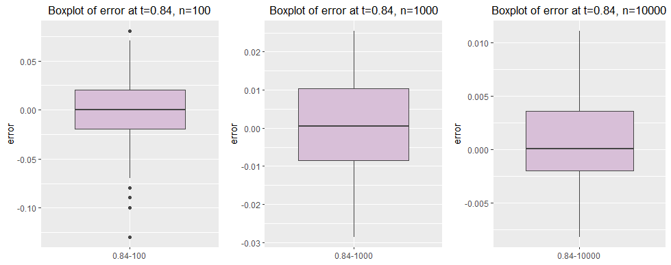

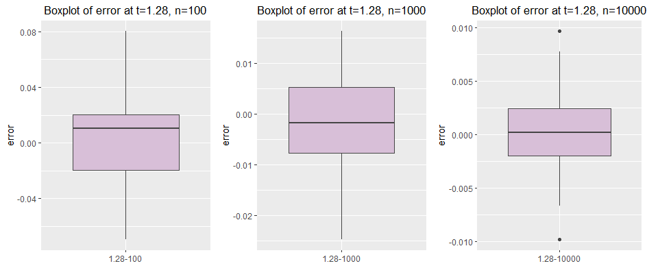

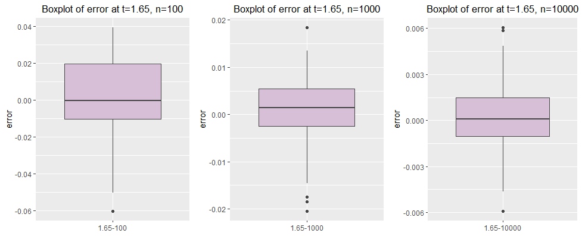

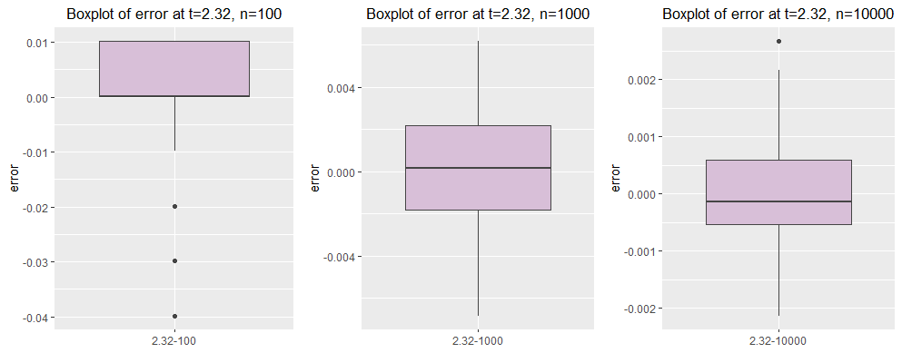

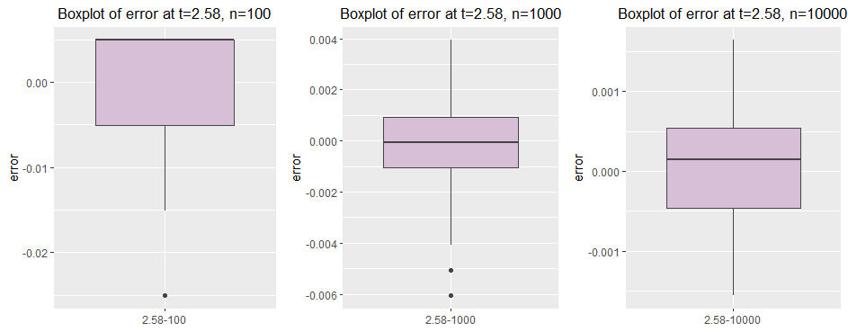

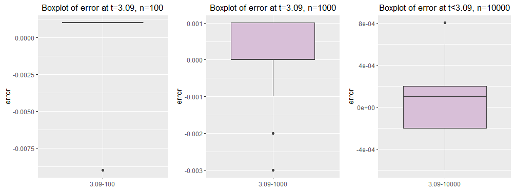

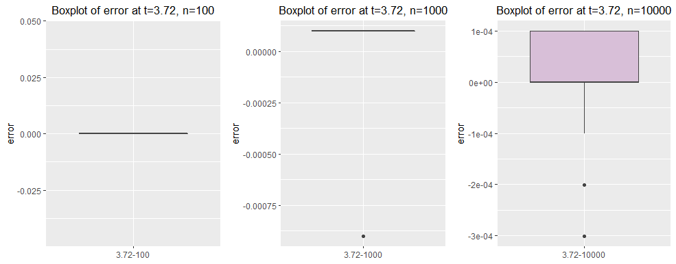

## 5 **R Code**

I’m sorry but I have to confess that my code is a reference to a classmate in the class

[Reference website：https://github.com/data-science-in-action/03-practicing-r-markdown-ly357](https://github.com/data-science-in-action/03-practicing-r-markdown-ly357)